# Bonanza Creek Experimentl Forest Juvenile Showshoe Hare Report

By: Meghan Fletcher

11/16/2020

## Introduction

This report uses various exploratory analyses to elaborate on the differences in juvenile snowshoe hare weights among individuals trapped in the Bonanza Creek Experimental Forest near Fairbanks, Alaska from 1998 to 2012 (Kielland et al. (2017)). In particular, the weights of these juvenile hares were analyzed and compared by sex and trap site. Additionally, juvenile snowshoe hare weight was analyzed in relation to the hind foot length of each individual trapped and recorded.

## Data and Analyses

From 1998 to 2012, Dr. Kielland and colleagues from the Bonanza Creek Station Long Term Ecological Research (LTER) network site collected data on snowshoe hares across three different locations within the Bonanza Creek Experimental Forest of Fairbanks, Alaska. From each trapping, measurements of sex, approximate age, weight and hind foot length were taken. Using exploratory data visualization methods, the weights of juvenile males and females were evaluated using a two-sample t-test with a significance level ($\alpha$) of 0.05. Using the Cohen’s d effect size, the differences between the two sexes were evaluated overall. Additionally, analysis of the relationship between juvenile snowshoe hare hind foot length and weight was performed using simple linear regression methods. Conditions of normalcy were considered using additional diagnostic tests (not shown in this report).

## Preliminary Results

### A. Annual juvenile snowshoe hare successful trap counts

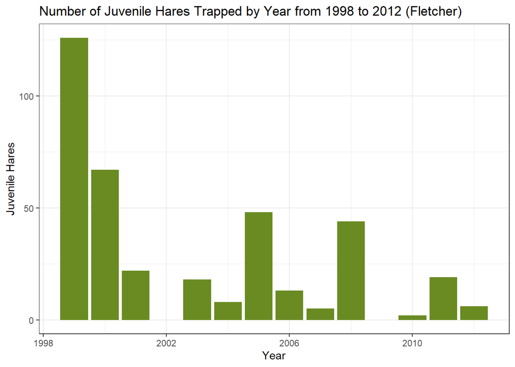

**Firgure 1:** Graph depicting the numbers of snowshoe hares caught for the study from 1998 to 2012. Years 1998, 2002 and 2009 appear to have no juvenile hares trapped. However, in the data set there are recorded captures but the age is unknown and represented as a value of NA. This leaves us with missing values for this year since we don’t know the age and cannot determmine if the captured hares were juveniles or adults. Data from Kielland et al. (2017).

There is a clear decline in the number of juvenile hares trapped from 1998 to 2012. The mean amount of traps per year can be rounded to 32 juvenile hares while the median can be rounded to 19 juvenile hares (since you can’t have half of a hare). Aside from any potential juvenile hares that may have been missed due to a lack of age recorded - the minimum number of juveniles trapped is 2 from 2010 and the maximum is 126 from 1999. Additionally, the standard deviation for these counts is 35.88 indicating that there seems to be a lot of variability in the number of successful trappings from year to year. This data could be more appropriately analyzed if there was consistency throughout the study. Moving forward, I would suggest that the team needs to set the same traps in the exact same locations across each year. Additionally, it is crucial that the data is coming from the same time-frames of each year so that other outside factors like seasonal variability aren’t impacting the overall data.

### B. Visualizing juvenile snowshoe hare weights by location and sex

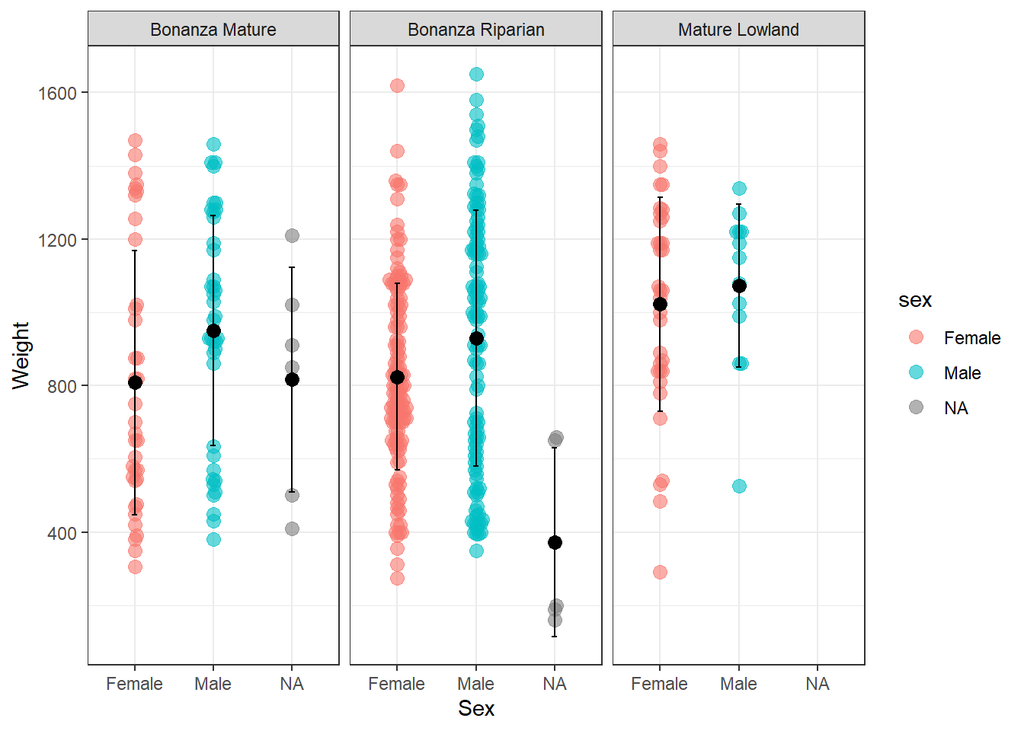

**Figure 2:** Graph used to visualize the differences in weight for juvenile snowshoe hares trapped throughout the study. These weigths are broken down by location and sex. NA values were included in grey to included juveniles that were trapped but whose sex was not recorded. Data from Kielland et al. (2017).

From this graph, we can see the differences in mean weight of females (pink) and males (blue) across the three trap locations used. By faceting the data in this way, we can see that juvenile males across all three study sites have a greater mean body weight than juvenile females recorded from those same locations. Both males and females appear to have greater average weights in the Mature Lowland than the other locations. However, there is not as great of a difference between the mean weights of males and females in the Mature Lowland as there is in the other two locations. The lowland location also has the lowest number of trappings which means it is potentially not as representative of the population’s mean weights due to the smalle sample size.

### C. Difference in male and female juvenile snowshoe hare weights based on summary statistics and additional exploratory analyses

**Table 1:** Descriptive statistics (mean, standard deviation, and sample size) for male and female juvenile snowshoe hares from the Bonanza Mature, Bonanza Riparian and Mature Lowland sites. NA values included for juveniles of unknown sex. Data: Kiedall et al. (2017).

Mean Summary Statistics for Male and Female Juvenile Showshoe Hare Weights

| grid | sex | mean_hare_weight | sd_hare_weight | sample_size |
| --- | --- | --- | --- | --- |
| Bonanza Mature | Female | 808.1944 | 361.1235 | 36 |
| Bonanza Mature | Male | 950.1250 | 314.6864 | 40 |
| Bonanza Mature | NA | 816.6667 | 307.0939 | 6 |
| Bonanza Riparian | Female | 824.1496 | 255.0350 | 127 |
| Bonanza Riparian | Male | 929.2727 | 349.1660 | 110 |
| Bonanza Riparian | NA | 372.0000 | 258.7856 | 5 |
| Mature Lowland | Female | 1022.0588 | 292.9632 | 34 |
| Mature Lowland | Male | 1073.0769 | 222.6408 | 13 |

From our exploratory analysis, we see that on average, male juvenile snowshoe hares have greater weights than females of the same age and species (945.86 $\pm$ 333.22 and 855.39 $\pm$ 292.25 grams, respectively; mean $\pm$ 1 standard deviation). The absolute difference in mean weights between male and female juvenile snowshoe hares is 90.47 grams (a 10.05% difference). Based on a significance level ($\alpha$) of 0.05, the difference in means is significant (Welch’s two-sample t-test: t(325.02) = 2.71, p = 0.007), but the effect size is small (Cohen’s *d* = 0.29). This means that there is indeed a real difference between means but further analysis would be suggested in order to more clearly identify this difference. Our p-value also tells us that there is a 0.7% probability that we would get samples with mean weights that are at least this different by random chance if they were taken from with populations with the same mean weights. Additionally, we can see that the weight of juvenile male snowshoe hares is greater than that of the females based on an alternative Welch’s two-sample t-test t(325.02) = 2.71, p = 0.003).

### D. Relationship between juvenile snowshoe hare weight and hind foot length

In our final analysis, the relationship between juvenile snowshoe hare weights and hind foot lengths was explored. This exploration included juvenile hares captured from 1998 to 2012. Additionally, this exploration is not faceted by sex or location, both of which could be contributing factors to any correlations identified between these two variables.

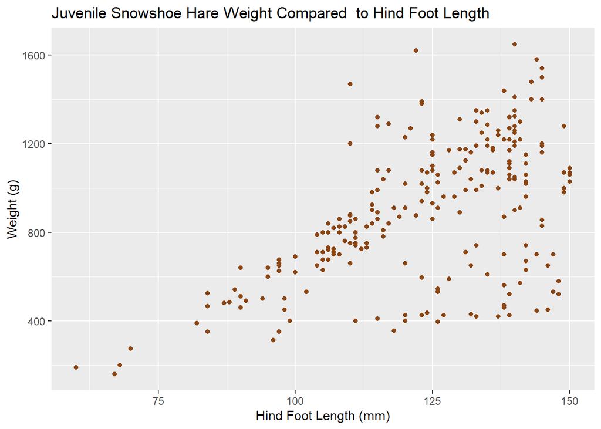

**Figure 3:** Graph representing the relationship between juvenile snowshoe hare weight and hind foot length. The graph appears to demonstrate a positive correlation between the two. However, we are missing important distinctions such as sex and location that might play a role in the relationship between these two variables. Linear model summary: $\beta$<sub>1</sub> = 9.52 g mm<sup>-1</sup>, p < 0.001, R<sup>2</sup> = 0.3, Pearson’s *r* = 0.55). Data: Kiedall et al. (2017).

From this exploratory analysis of juvenile snowshoe hare weight and hind foot length, we found that the relationship between the two variables is relatively linear. Our linear regression modeling showed that hind foot length significantly predicts juvenile snowshoe hare weight (p < 0.001, R<sup>2</sup> = 0.3) with an average slope of $\beta$ = 9.52 g mm<sup>-1</sup>. This means that for each one millimeter increase in hind foot length, we expect an average increase in hare weight by 9.52 grams. From these results, we can see that juvenile snowshoe hare hind foot length and weight are strongly, and significantly, positively correlated (Pearson’s *r* = 0.55, p < 0.001). Based on our diagnostic plots used to evaluate normalcy and residual patterns, it is hard to determine the legitimacy of these results. From these diagnostic plots (not shown here), we found that the plots appear to primarily reveal normally distributed and homoscedastic residuals. However, both the Residuals vs. Fitted plot and the Normal Q-Q plot indicate uneven distribution among residual values. The discrepancies in these plots are likely due to the fact that the data has not been faceted by sex and trap location.

## Summary

From our exploratory data analysis, we found the following:

- The number of juvenile hare trappings majorly decreased from 1998 to 2012 (more consistency in trapping and age identification would potentially alter these findings).
- Male juvenile snowshoe hares are heavier, on average, than female juvenile snowshoe hares across the Bonanza Mature, Bonanza Riparian and Mature Lowland sites used for trapping hares near Fairbanks, Alaska.
- Juvenile snowshoe hare hind foot length and weight appear to be positively correlated (with a 1mm increase in hind foot length resulting in a 9.52 increase in weight (g)).
- Final results of the hind foot length vs. weight analysis should be viewed cautiously since neither sex nor location were used to differentiate the data.
- To improve this study, a more precise approach to trapping each year in addition to consistency in recording approximate age would make the results more definitive.

## Citations

Kielland, K., F.S. Chapin, R.W. Ruess, and Bonanza Creek LTER. 2017. Snowshoe hare physical data in Bonanza Creek Experimental Forest: 1999-Present ver 22. Environmental Data Initiative. https://doi.org/10.6073/pasta/03dce4856d79b91557d8e6ce2cbcdc14